# An Analysis of Thrones

Brett Olson

December 20, 2017

## Character Death Prediction

### Gender and Nobility

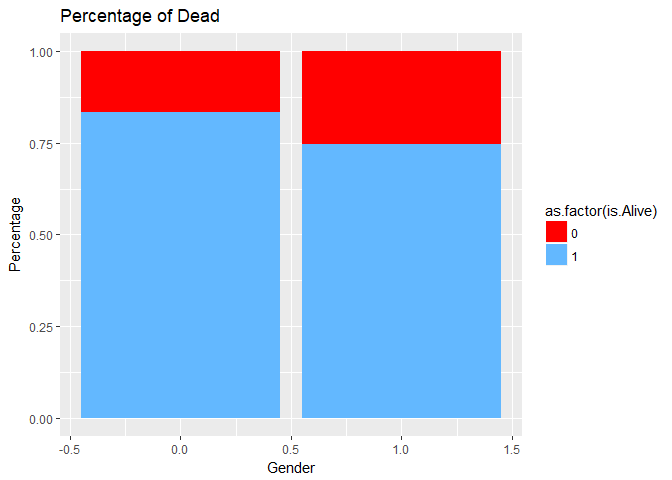

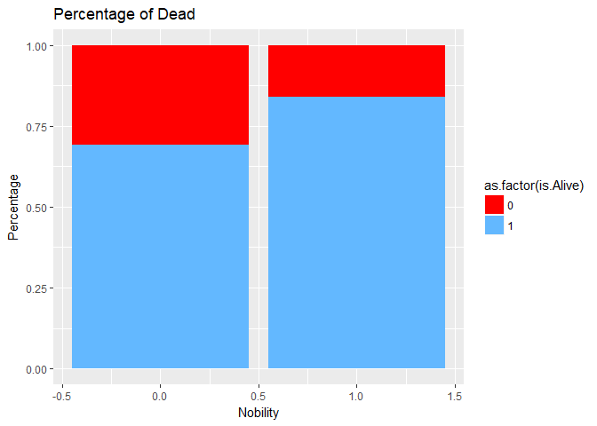

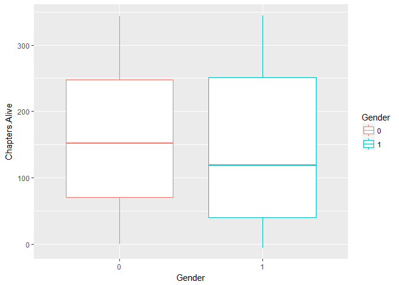

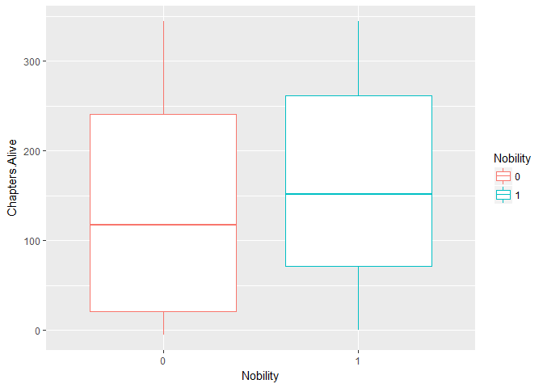

There isn’t a ton of difference on either boxplots except the means for chapters alive of the side that had a higher percentage dying is lower than the contrary. The last factor that was offered in the kaggle dataset was the allegiance of each person.

### Allegiance

The last factor that was offered in the kaggle dataset was the allegiance of each person. Although, there is a difference between a house and name. For example, an allegiance can be to the name Tully which would be royalty in that family or to House Tully which would be to the whole kingdom of the Tully House. There are so many allegiances to where the allegiance of an individual will most likely affect the probability of their death.

[figure not shown]

### Model and Trees

Therefore, with all of these factors plus an additional one with the Intro Chapter of the character to help with the death prediction we can use multiple models to see where each person falls. The first one we will look at is a linear model and how each factor affects the probability of a person with certain attributes dying.

```
##
## Call:
## lm(formula = is.Alive ~ Intro.Chapter + Gender + Nobility + Allegiances,
##     data = is_alive_people)
##
## Residuals:
##      Min       1Q   Median       3Q      Max
## -1.00431 -0.00639  0.13894  0.25017  0.63826
##
## Coefficients:
##                              Estimate Std. Error t value Pr(>|t|)
## (Intercept)                 0.8933897  0.1016245   8.791  < 2e-16 ***
## Intro.Chapter               0.0003575  0.0001673   2.137 0.032910 *
## Gender                     -0.0737159  0.0391323  -1.884 0.059971 .
## Nobility                    0.0867390  0.0337231   2.572 0.010294 *
## AllegiancesBaratheon       -0.0958971  0.1075596  -0.892 0.372899
## AllegiancesGreyjoy         -0.0812246  0.1061365  -0.765 0.444335
## AllegiancesHouse Arryn     -0.0490246  0.1887118  -0.260 0.795098
## AllegiancesHouse Baratheon -0.4840291  0.1764090  -2.744 0.006214 **
## AllegiancesHouse Greyjoy   -0.4765999  0.1223085  -3.897 0.000106 ***
## AllegiancesHouse Lannister -0.3908159  0.1353445  -2.888 0.003990 **
## AllegiancesHouse Martell   -0.0652718  0.1482892  -0.440 0.659940
## AllegiancesHouse Stark     -0.2864256  0.1199368  -2.388 0.017173 *
## AllegiancesHouse Targaryen  0.0226859  0.1350225   0.168 0.866615
## AllegiancesHouse Tully     -0.3801078  0.1877952  -2.024 0.043307 *
## AllegiancesHouse Tyrell     0.0453120  0.1555197   0.291 0.770855
## AllegiancesLannister       -0.0340916  0.1005329  -0.339 0.734619
## AllegiancesMartell         -0.0672007  0.1201346  -0.559 0.576065
## AllegiancesNight's Watch   -0.1867610  0.1013627  -1.843 0.065783 .
## AllegiancesNone            -0.1524765  0.0934710  -1.631 0.103239
## AllegiancesStark           -0.2252507  0.1021336  -2.205 0.027715 *
## AllegiancesTargaryen       -0.2076135  0.1329208  -1.562 0.118712
## AllegiancesTully           -0.0364605  0.1261988  -0.289 0.772725
## AllegiancesTyrell          -0.0520699  0.1369218  -0.380 0.703835
## AllegiancesWildling        -0.4718014  0.1132558  -4.166 3.45e-05 ***
## ---
## Signif. codes:  0 '***' 0.001 '**' 0.01 '*' 0.05 '.' 0.1 ' ' 1
##
## Residual standard error: 0.4035 on 775 degrees of freedom
##   (2 observations deleted due to missingness)
## Multiple R-squared:  0.1256, Adjusted R-squared:  0.09964
## F-statistic:  4.84 on 23 and 775 DF,  p-value: 1.623e-12
```

```
##
## Call:
## lm(formula = Chapters.Alive ~ Gender + Nobility + Allegiances,
##     data = is_alive_people)
##
## Residuals:
##      Min       1Q   Median       3Q      Max
## -218.503  -89.158   -7.813   91.870  232.905
##
## Coefficients:
##                            Estimate Std. Error t value Pr(>|t|)
## (Intercept)                 178.801     25.767   6.939 8.33e-12 ***
## Gender                      -15.054     10.257  -1.468 0.142589
## Nobility                     22.597      8.852   2.553 0.010875 *
## AllegiancesBaratheon         12.235     28.172   0.434 0.664202
## AllegiancesGreyjoy          -74.497     27.640  -2.695 0.007185 **
## AllegiancesHouse Arryn       52.802     49.338   1.070 0.284856
## AllegiancesHouse Baratheon  -58.517     46.235  -1.266 0.206021
## AllegiancesHouse Greyjoy    -76.249     32.065  -2.378 0.017652 *
## AllegiancesHouse Lannister  -48.903     35.449  -1.380 0.168127
## AllegiancesHouse Martell    -81.361     38.708  -2.102 0.035884 *
## AllegiancesHouse Stark       14.767     31.100   0.475 0.635046
## AllegiancesHouse Targaryen   12.053     35.396   0.341 0.733558
## AllegiancesHouse Tully      -22.946     49.166  -0.467 0.640839
## AllegiancesHouse Tyrell      11.073     40.771   0.272 0.786007
## AllegiancesLannister         17.105     26.332   0.650 0.516140
## AllegiancesMartell          -61.600     31.342  -1.965 0.049726 *
## AllegiancesNight's Watch     -8.231     26.548  -0.310 0.756611
## AllegiancesNone             -41.517     24.484  -1.696 0.090345 .
## AllegiancesStark            -48.097     26.773  -1.796 0.072805 .
## AllegiancesTargaryen        -76.573     34.819  -2.199 0.028160 *
## AllegiancesTully             26.820     33.052   0.811 0.417358
## AllegiancesTyrell             7.168     35.893   0.200 0.841774
## AllegiancesWildling        -100.363     29.607  -3.390 0.000735 ***
## ---
## Signif. codes:  0 '***' 0.001 '**' 0.01 '*' 0.05 '.' 0.1 ' ' 1
##
## Residual standard error: 105.8 on 775 degrees of freedom
##   (3 observations deleted due to missingness)
## Multiple R-squared:  0.1174, Adjusted R-squared:  0.09232
## F-statistic: 4.685 on 22 and 775 DF,  p-value: 1.443e-11
```

Interactive models make no difference and just add more complexity to the model, so these are avoided in this case. As we can see there are certain houses that have less percentage of dead people and they have a better chance to live throughout the books and longer. Such as the Wildlings, House Baratheon, and House Greyjoy have the largest negative impact on living. Although, living and how long someone lives are not necessarily correlated. Also, there is an interesting upward trend on the later a character is introduced the higher chance they have to live. Again, our early exploratory analysis showed that the Gender and Nobility variables will affect their living probability accordingly.

The next model that should show a good prediction is a regression tree. This regression tree is going to take into account all 4 of the variables mentioned in the previous model and build a tree. This tree will go through the several factors and weigh how much each one affects the outcome and make factors more prevalent if they influence the end result. This regression tree will follow how many people that it splits and the probability of life in each step. The same is true for the regression tree for the amount of chapters the individual will sustain life.

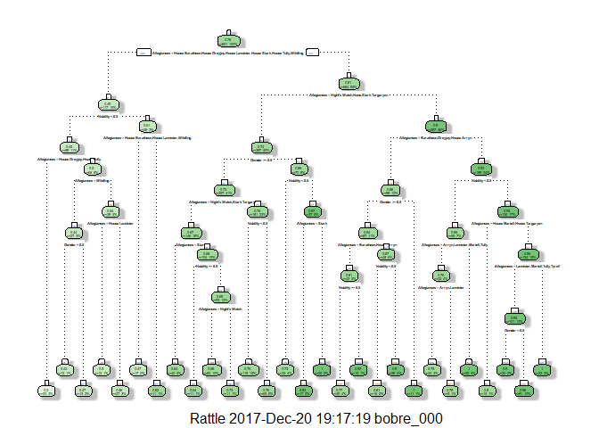

[figure not shown]

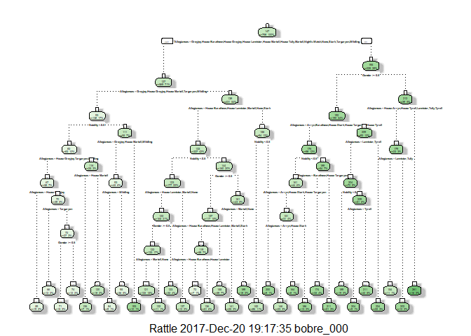

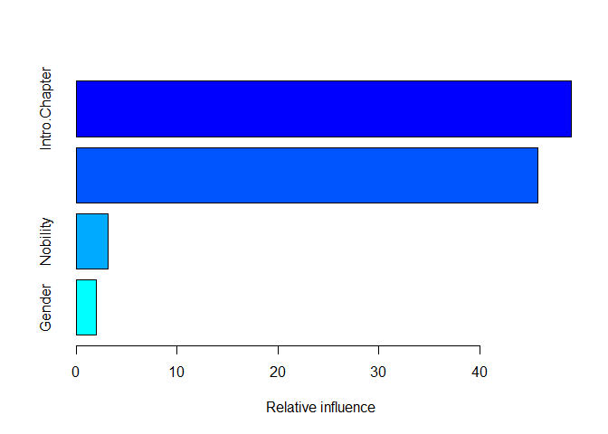

```
##                         var   rel.inf
## Intro.Chapter Intro.Chapter 49.084441
## Allegiances     Allegiances 45.762182
## Nobility           Nobility  3.136332
## Gender               Gender  2.017046
```

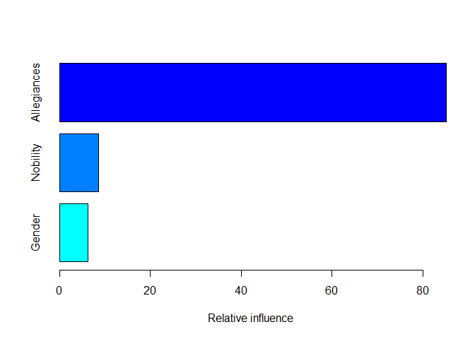

```
##                     var   rel.inf
## Allegiances Allegiances 85.176564
## Nobility       Nobility  8.604682
## Gender           Gender  6.218754
```

After looking at these trees we can see that Allegiance and Intro.Chapter both have the most separation steps. To give a number to how much each factor influences the end result we make a gradient boosted tree. To do this, the program takes many trees (I used 5000) to create a forest, using different combinations of the factors. After this many iterations it should become obvious which factors take are important to the characters future. The first tree does not have the variable Intro.Chapter in it and the second tree does. Then the last tree shows the chapters alive prediction. The first gradient boosted tree shows the model from the second tree. Then the second gradient boosted tree is from the chapters alive model. Gender and Nobility really don’t have a big impact on death or the chapters that a charaacter is going to survive. We could have made this conclusion from the sparsity of these two factors in the trees, however it is nice to have a number to compare.

## Book vs Show

For as long as I can remember there has been comparisons made between books and the movies that have come out of them. In this specific instance, the first book in the Song of Fire and Ice series, “Game of Thrones”, can be seen as very similar to its tv counterpart. The first season in the Game of Thrones television series is suppose to match pretty well with the first book by George R.R. Martin. The goal is to take an overall perspective, instead of a scenario by scenario perspective, like which scenes are in or out of the book or show. For an overall perspective, the focus is on sentiment of each or the total feeling of each, perspectives of main characters, and similarities between words used in both.

### Sentiment

The first thing that would help compare these two would be the plot sentiment arcs. However, the book is written in different perspectives for each chapter. Thus trying to line these up with what is happening in the show is nearly impossible. Therefore, with sentiment arcs out of the picture, we still turn to sentiment from the nrc dictionary. This dictionary takes each word and categorizes it into one of ten categories (Anger, Anticipation, Disgust, Fear, Joy, Negative, Positive, Sadness, Surprise, and Trust).

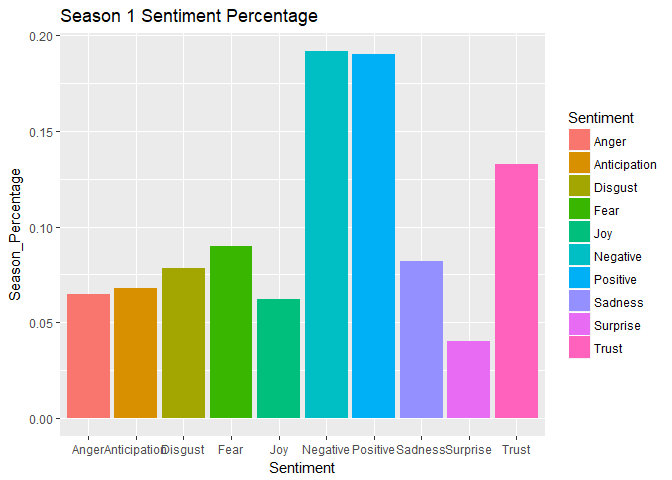

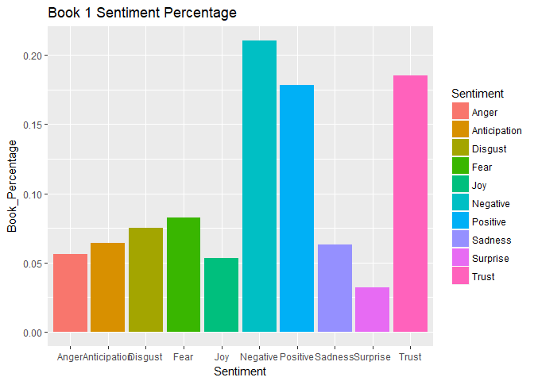

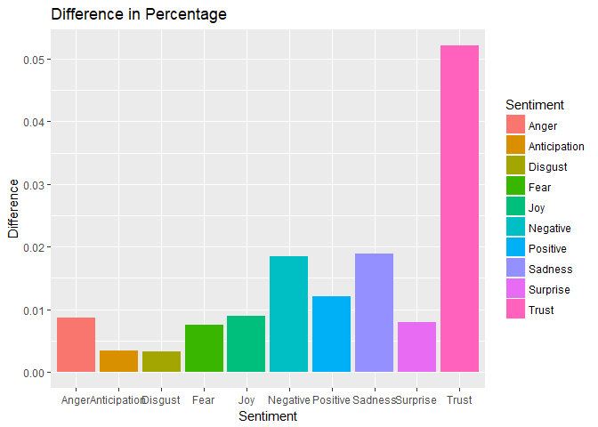

It can be seen that there is not a huge difference between these words from the book to that of the movie besides trust. Although every other sentiment category is under 2%, which is very good. Thus, the overall feeling of the book is very close to the show.

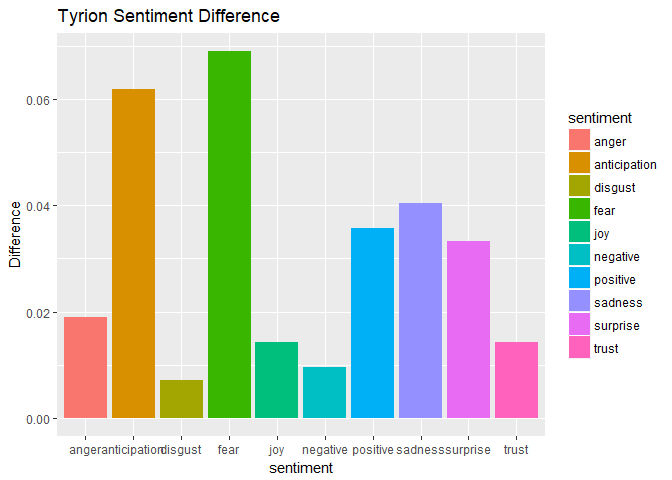

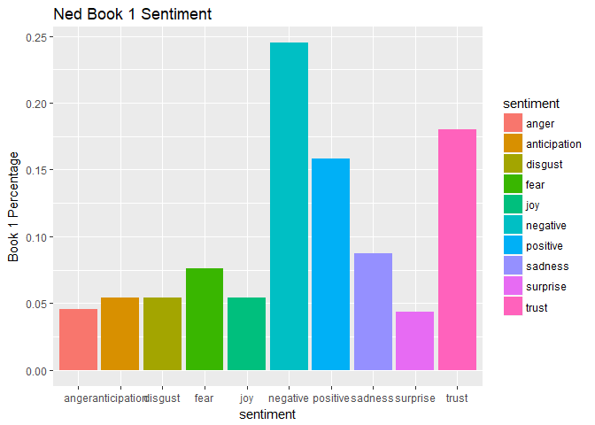

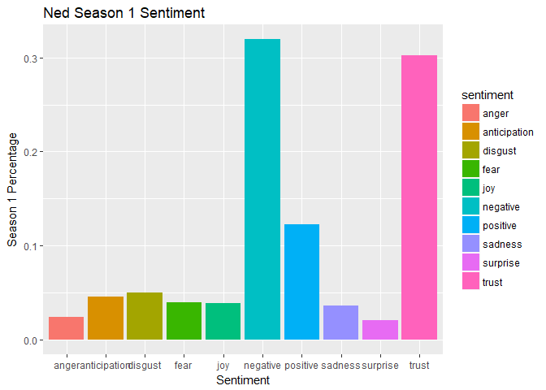

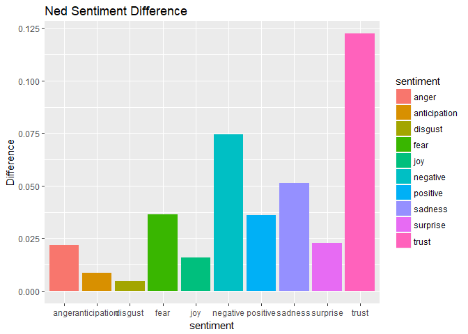

### Word Frequency

The next comparison technique is words of both. A good way to compare words between documents is a wordcloud. The first set of wordclouds is of names and characters. The second is of other words. They are very similar and there is not a lot of major differences. However, to actually have a numerical significance in difference of the two regarding words, we can use term frequency.

[figure not shown]

```r
lines_season1 <- rbind(lines_s1e1_nonstop,lines_s1e2_nonstop,lines_s1e3_nonstop,lines_s1e4_nonstop,lines_s1e5_nonstop,lines_s1e6_nonstop,lines_s1e7_nonstop,lines_s1e8_nonstop,lines_s1e9_nonstop,lines_s1e10_nonstop)

wordcount_book1 <- lines_book1 %>%
  count(word,sort=TRUE)
wordcount_season1 <- lines_season1 %>%
  count(word,sort=TRUE)

characters <- read.csv("C:/Users/bobre_000/Documents/Data Science/Project Materials/Characters.csv")
book1characters <- characters %>%
  filter(Page<= 764,Book=="A Game of Thrones")
book1Forenames <- book1characters %>%
  select(Forename) %>%
  group_by(Forename) %>%
  summarize(total=n()) %>%
  select(Forename) %>%
  slice(2:n()) %>%
  setnames(old=("Forename"),new=("Name"))

book1Surnames <- book1characters %>%
  select(Surname) %>%
  group_by(Surname) %>%
  summarize(total=n()) %>%
  select(Surname) %>%
  slice(2:n()) %>%
  setnames(old=("Surname"),new=("Name"))
book1names <- rbind(book1Forenames,book1Surnames)
book1names <-  tibble(tolower(book1names$Name))
names(book1names) <- c("Name")
Name <- c('dany','ned','imp','hound','mountain','littlefinger')
Name <- data.frame(Name)
book1names <- rbind(book1names,Name)
book1namecount <- wordcount_book1 %>%
  inner_join(x=wordcount_book1,y=book1names,by=c('word'='Name')) %>%
  mutate(Book_or_Show = "Book")
season1namecount <- wordcount_season1 %>%
  inner_join(x=wordcount_season1,y=book1names,by=c('word'='Name'))%>%
  mutate(Book_or_Show = "Show")
library(wordcloud)
wordcloud(season1namecount$word,             # column of words
          season1namecount$n,                # column of frequencies
          scale=c(5.5,0.2),                 # range of font sizes of words
          max.words=200,                  # show the 200 most frequent words
          random.order=FALSE,             # position the most popular words first
          colors=brewer.pal(8, "Dark2"))  # Color palette
```

[figure not shown]

```r
wordcloud(book1namecount$word,             # column of words
          book1namecount$n,                # column of frequencies
          scale=c(5,0.2),                 # range of font sizes of words                  # minimum word frequency to show
          max.words=200,                  # show the 200 most frequent words
          random.order=FALSE,             # position the most popular words first
          colors=brewer.pal(8, "Dark2"))  # Color palette
```

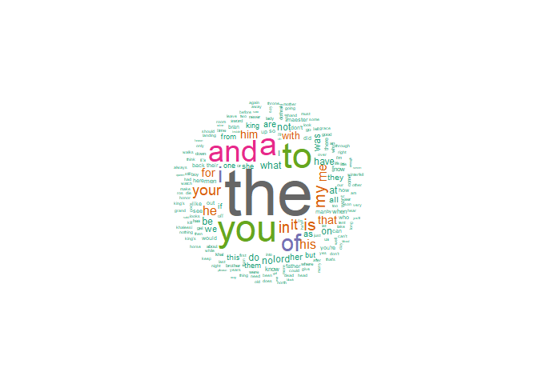

```r
analysis_book1_season1 <- rbind(season1namecount,book1namecount)
tfidf_analysis<- analysis_book1_season1%>%
  bind_tf_idf(word, Book_or_Show, n) %>%
  arrange(desc(tf_idf))


book1nonnamecount <- wordcount_book1 %>%
  anti_join(x=wordcount_book1,y=book1names,by=c('word'='Name')) %>%
  mutate(Book_or_Show = "Book")


season1nonnamecount <- wordcount_season1 %>%
  anti_join(x=wordcount_season1,y=book1names,by=c('word'='Name')) %>%
  mutate(Book_or_Show = "show")


library(wordcloud)
wordcloud(season1nonnamecount$word,             # column of words
          season1nonnamecount$n,                # column of frequencies
          scale=c(5,0.2),
          min.freq = 10,# range of font sizes of words
          max.words=200,                  # show the 200 most frequent words
          random.order=FALSE,             # position the most popular words first
          colors=brewer.pal(8, "Dark2"))  # Color palette
```

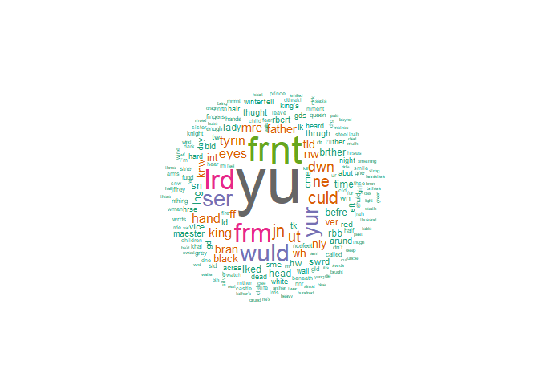

```r
wordcloud(book1nonnamecount$word,             # column of words
          book1nonnamecount$n,                # column of frequencies
          scale=c(5,0.2),
          min.freq = 15,# range of font sizes of words                  # minimum word frequency to show
          max.words=200,                  # show the 200 most frequent words
          random.order=FALSE,             # position the most popular words first
          colors=brewer.pal(8, "Dark2"))  # Color palette
```

```r
analysis_book1_season1_nonname <- rbind(season1nonnamecount,book1nonnamecount)
tfidf_analysis_nonname<- analysis_book1_season1_nonname%>%
  bind_tf_idf(word, Book_or_Show, n) %>%
  arrange(desc(tf_idf))
```

Comparing the two documents using raw word count would not be useful at all considering the large disparity of actual content between the book and the show. The book has so much more actual text than the scripts. Therefore, we use term frequency and inverse document frequency. Term frequency is the logarithm of the word count. Inverse document frequency takes the logarithm of the the amount of documents containing the word divided by the total number of documents being examined. Then we multiply these two numbers. The terms with the highest tf-idf score will be words or people that are not mentioned much in one of the documents but is mentioned a fair amount in the other.

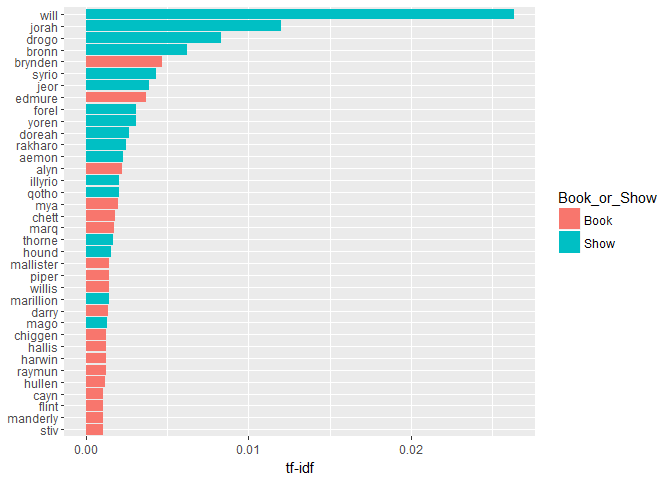

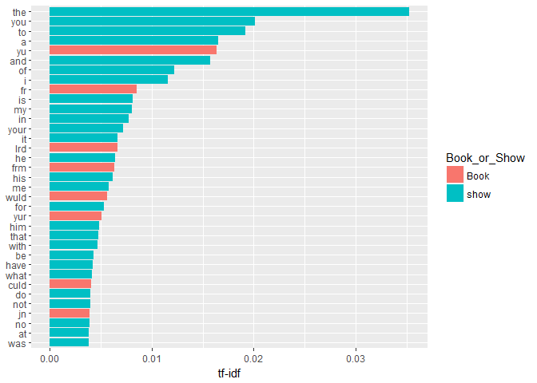

The show is getting the general feel of the series through sentiment and through characters somewhat. The perception of characters is the only thing that really was a disagreement with the two being the same. There were really no discrepancies regarding words within each either. Thus, they are not leaving out important characters or story plots. Overall, the show is doing a pretty good job, at least in the first season.